# Machine Learning and Stats Playground

# Ayokiitan Akala

#### Worked with Imad Khokher, Kweku Aggrey

```python
import warnings
warnings.filterwarnings('ignore')
import sklearn
from sklearn import datasets
import statsmodels.api as sm
import matplotlib
import numpy as np
import scipy as sp
import pandas as pd
from ggplot import *
import seaborn as sns
import statsmodels.api as sm
import matplotlib.pyplot as plt
from sklearn import linear_model
import statsmodels.formula.api as smf
import matplotlib; matplotlib.style.use('ggplot')
from sklearn.preprocessing import PolynomialFeatures
data = pd.read_csv("gap.tsv", sep='\t')
data.head()
```

|  | country | continent | year | lifeExp | pop | gdpPercap |
| --- | --- | --- | --- | --- | --- | --- |
| 0 | Afghanistan | Asia | 1952 | 28.801 | 8425333 | 779.445314 |
| 1 | Afghanistan | Asia | 1957 | 30.332 | 9240934 | 820.853030 |
| 2 | Afghanistan | Asia | 1962 | 31.997 | 10267083 | 853.100710 |
| 3 | Afghanistan | Asia | 1967 | 34.020 | 11537966 | 836.197138 |
| 4 | Afghanistan | Asia | 1972 | 36.088 | 13079460 | 739.981106 |

## Exercise 1

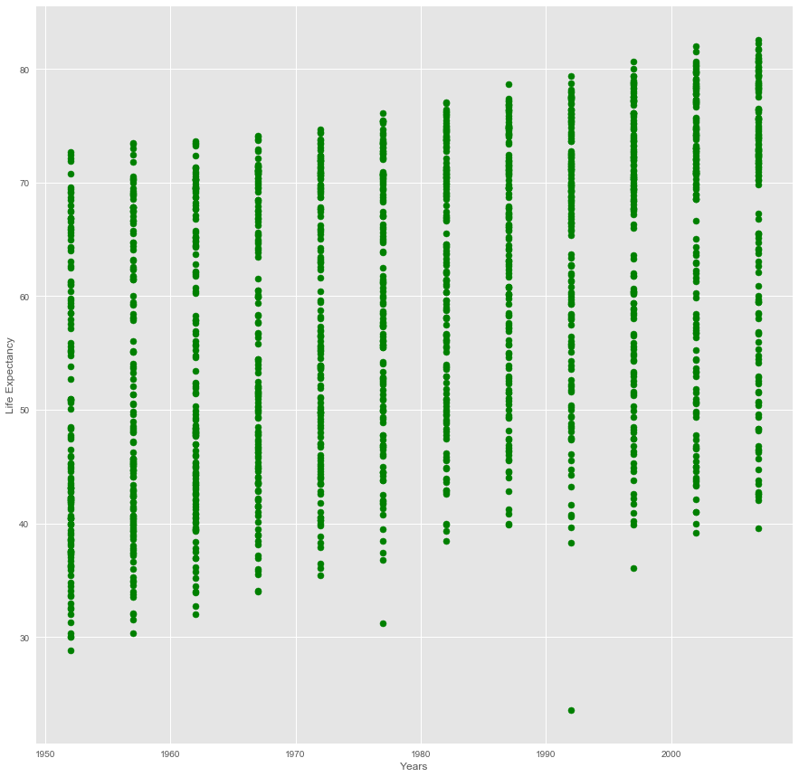

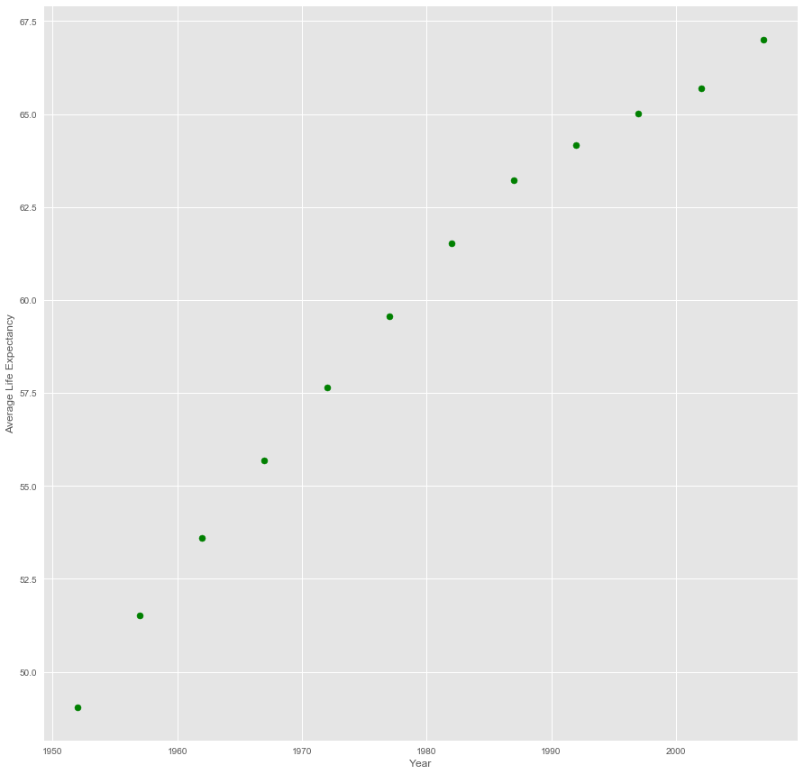

```python
plt.figure(figsize=(15, 15))
plt.scatter( data['year'], data['lifeExp'],c="green")
plt.xlabel("Years")
plt.ylabel("Life Expectancy")
plt.show()

lifeExpAvgs = data.groupby('year')['lifeExp'].mean()
uniqueYears = data['year'].unique()
plt.figure(figsize=(15, 15))
plt.scatter(uniqueYears, lifeExpAvgs,c="green")
plt.xlabel("Year")
plt.ylabel("Average Life Expectancy")
plt.show()
```

## Question 1

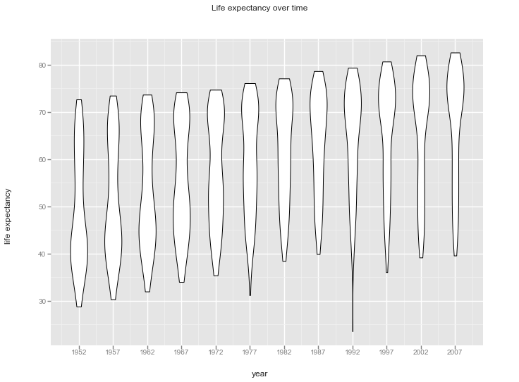

```python
ggplot(aes(x='year', y='lifeExp'), data=data) +\
    geom_violin() +\
    labs(title="Life expectancy over time",
         x = "year",
         y = "life expectancy")
```

## Question 2

For the earlier years, we can see that there is a fair emount of right skew as the data is mostly unimodal and clusterd towards the lower expectancy values. There are some countries that are at the higher end of the expectancy spectrum, however this represnts the minority of cases. In the middle range of years, we see the distribution of expectancy is somewhat symmetric, however we begin to see slight left skew in the data, but the data is mostly uniform. For the later years, we see a left skew develop, and the data begins to look more sharply unimodal in constrast to its proceeding years. For each year, the center of the distribution increases in addition to the lower and upper bounds of the range of values seen, with few exceptions.

## Question 3

I believe I agree that there is no relationship. There is an obvious positive trend in the data which might suggest that there is a relationship between year and life expectancy, however the large range of values for each year will make it difficult to create a model that can accurately account for all of the exhibited variance.

However if we increase our sample size we can probably ascertain a relationship with respect to the law oflarge numbers. Due to the variance of this sample space we cannot really accept any relationship due to the high about of noise in such a small sample space.

## Question 4

Because of the pretty strong correlation between year and life expectancy, I suspect a violin plot of the residuals would look very similar to the previous violin plot of the data. A regression would probably result in the same occurrence of variance that can be seen in the actual distribution, and for this reason the distributions of the violin plots for the residuals and the actual data probably look very similar. The violin plot for the residuals would probably just be a slimmer representation of the data. However, the modality and skews of each violin should be about the same.

## Question 5

In theory, a proper regression should have minimal variance therefore for each year, the violin would be centered around 0, and would be very spread to imply that each occurrence was properly predicted by the regression, and consequently each residual is 0.

## Exercise 2

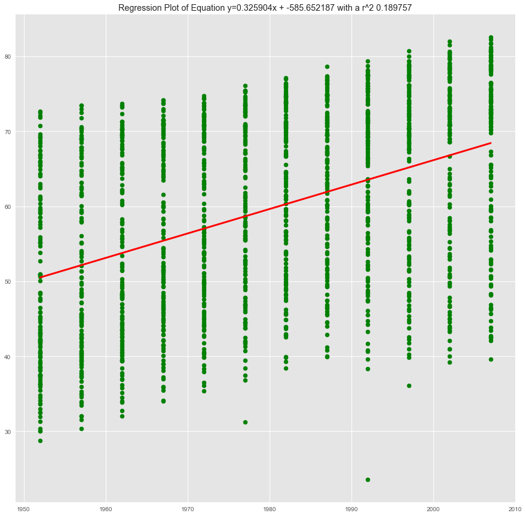

```python
plt.figure(figsize=(15, 15))

regr = linear_model.LinearRegression()
regr.fit(data['year'].values.reshape(-1,1), data['lifeExp'].values.reshape(-1,1))

y_pred = regr.predict(data['year'].unique().reshape(-1,1))


plt.plot(data['year'].unique(), y_pred, color='red', linewidth=3)
plt.scatter(data['year'], data['lifeExp'],c ="green")
plt.title("Regression Plot of Equation y=%fx + %f with a r^2 %f" %(regr.coef_,regr.intercept_, regr.score(data['year'].reshape(-1,1), data['lifeExp'])))
plt.show()
```

## Question 6

According to the data, the life expectancy increases by 0.325904 each year.

## Exercise 3

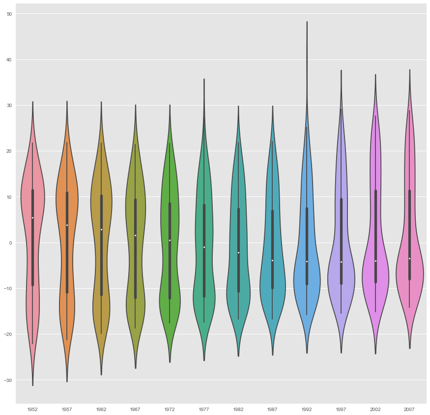

```python
firstModelY = regr.predict(data['year'].values.reshape(-1,1))
firstModelRes = firstModelY.reshape(len(firstModelY)) - data['lifeExp'].values

fig = plt.figure()
plt.figure(figsize=(15, 15))
plot = sns.violinplot(x=data['year'].values, y=firstModelRes)
plt.show()
```

## Question 8

As you can see from the plot above, the residuals are not what should be expected from a perfect regeression. The violins are not symmetrical for any grouping of years and are tending towards negative values, rather than being centered at zero. The lack of symmetry in the violins, in combination with the negative measure of center, indicates a poor regression. What is displayed above matches our assumptions.

We start to see very similar violin figures in years 1952 - 1967 and then the violins begin to transmorgrify into different shapes which corresponds to our data moving away from that relastionship. We can see in 2007 all similarities in violins are lost and our bulge moved from the top of the center to the bottom of the center.

## Exercise 4 (Violin Plot)

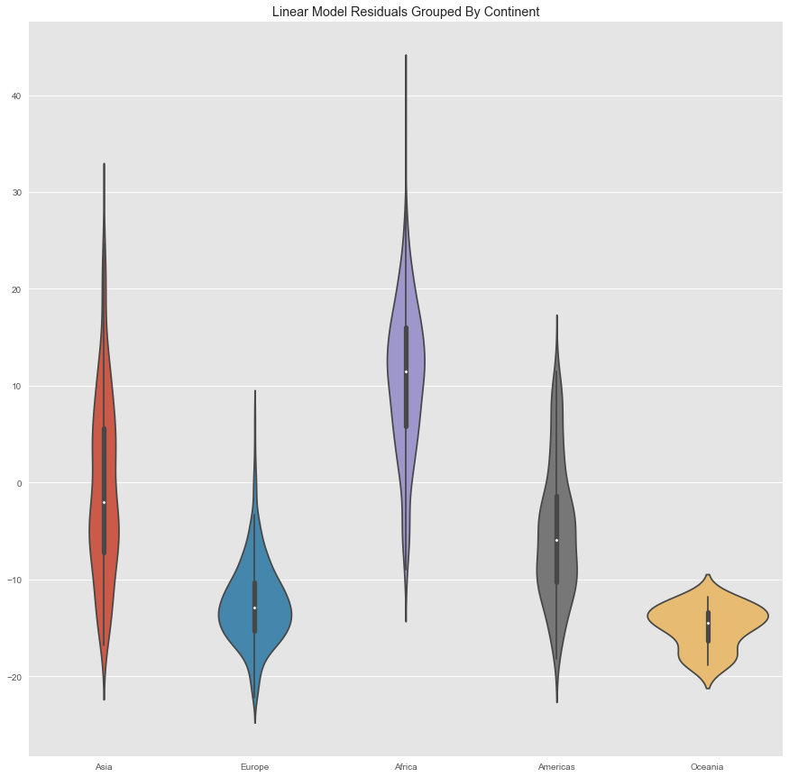

```python
fig = plt.figure()
plt.figure(figsize=(15, 15))
plot = sns.violinplot(x=data['continent'].values, y=firstModelRes)
plt.title("Linear Model Residuals Grouped By Continent")
plt.show()
```

## Exercise 5

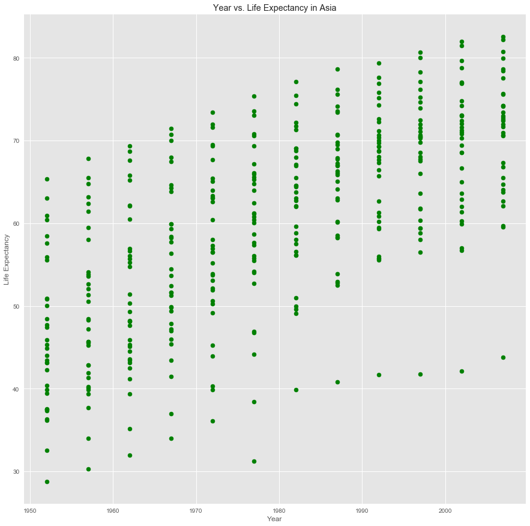

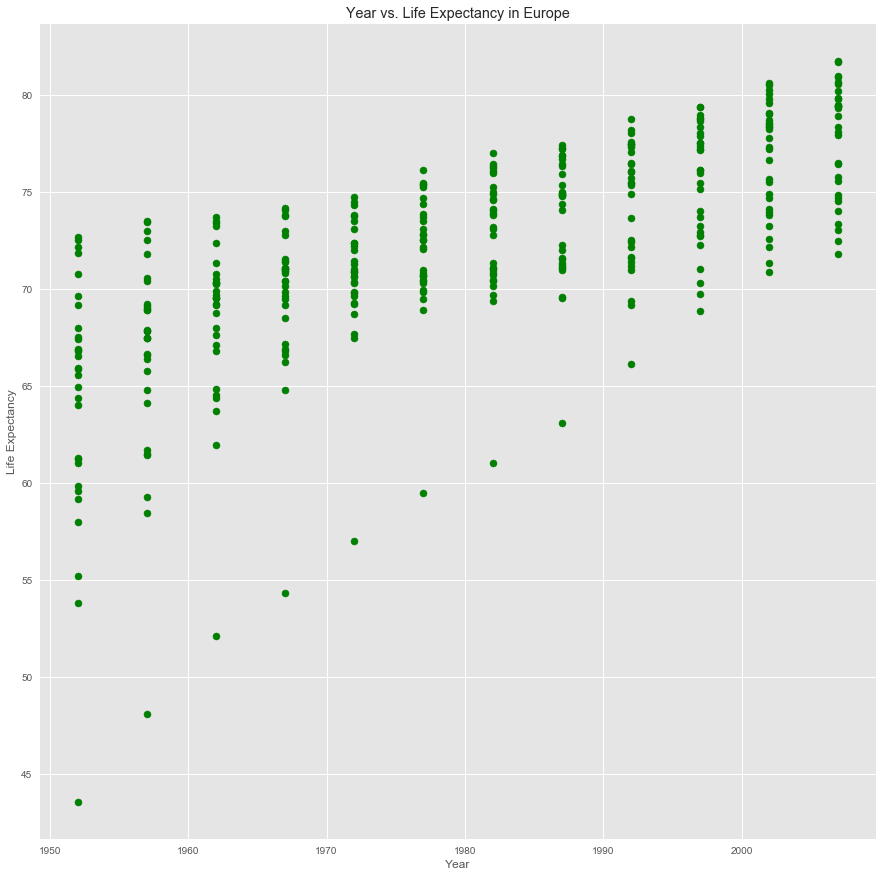

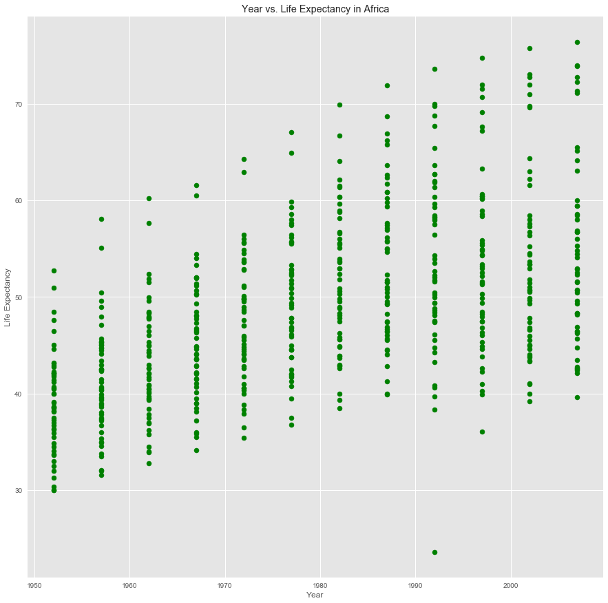

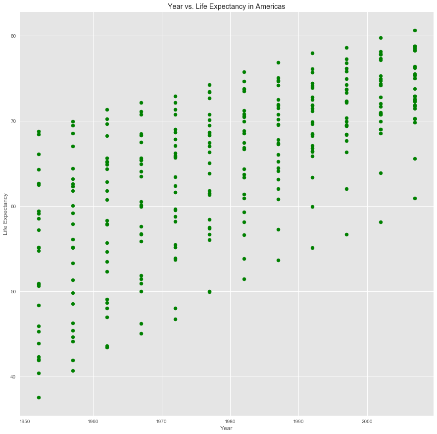

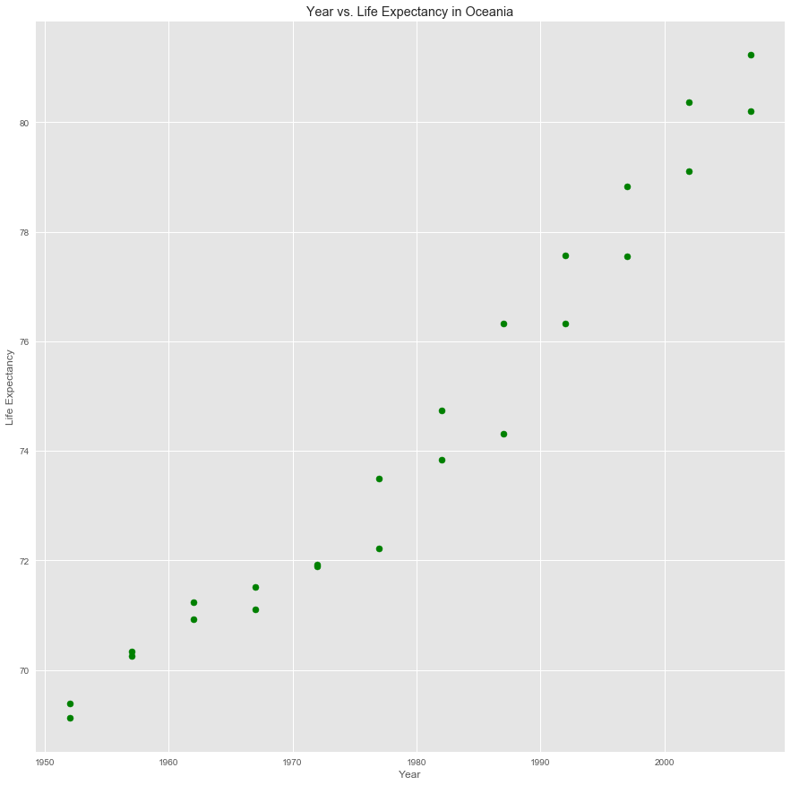

```python
for c in data['continent'].unique():
    plt.figure(figsize=(15, 15))
    plt.scatter(data[data['continent'] == c]['year'], data[data['continent'] == c]['lifeExp'],color="green")
    plt.xlabel("Year")
    plt.ylabel("Life Expectancy")
    plt.title("Year vs. Life Expectancy in %s" % c)
    plt.show()
```

## Question 10

Based on these plots I do not believe the regression should include a parameter for continent. Even though there is a general trend for each continent, there is still a rather high amount of variability in the data, adding a year term will make the data messy and hard to interpret. Clumping them up we can see that the variance will naturally coalesce back in to a less correlating figure. In conclusion I think that year and continent are both good delimiters although they would be better isolated.

## Exercise 6

```python
def encodeContinent(c):
    if c == 'Africa':
        return -2
    elif c == 'Americas':
        return -1
    elif c == 'Europe':
        return 1
    elif c == 'Oceania':
        return 2
    elif c == 'Asia':
        return 3

data['encodedContinent'] = data['continent'].map(encodeContinent)
X = data[['encodedContinent','year']]
y = data['lifeExp']

interaction = PolynomialFeatures(degree=1, include_bias=False, interaction_only=True)
X_inter = interaction.fit_transform(X)
regr = linear_model.LinearRegression()
model = regr.fit(X_inter, y)
print("The generalized slope is %f\nThe interaction term is %f" % (regr.coef_[0], regr.coef_[1]))
```

```
The generalized slope is 2.578822
The interaction term is 0.325904
```

## Question 12

The average life expectancy increases each for each continent where $\beta_1$ is the average slope increase of the regression, and $\beta_2$ is the slope increase of the interaction term. $x_1$ is the year and $x_2$ is the interaction term:

## $y=\beta_0 +\beta_1x_1 + \beta_2x_1x_2$

It follows that the average increase for each continent is the sum of the slope of the interaction term and the linear term:

## $(\beta_1 + \beta_2x_2)x_1$

See below the average increase for each continent:

```python
regre = smf.ols(formula= "lifeExp ~ year * continent ", data = data).fit()

for e in data['continent'].unique():
    x = regre.predict(pd.DataFrame({"continent": [e] , "year": 2000})) - regre.predict(pd.DataFrame({"continent": [e], "year": 1999}))
    print("The average increase in %s is %f" % (e, x))
```

```
The average increase in Asia is 0.453122
The average increase in Europe is 0.221932
The average increase in Africa is 0.289529
The average increase in Americas is 0.367651
The average increase in Oceania is 0.210272
```

## Exercise 7

```python
secondModelY = regr.predict(data[['encodedContinent','year']])

linearModel = np.transpose([data['year'],firstModelY.reshape(data['year'].shape)])
interactionModel = np.transpose([data['year'],secondModelY.reshape(data['year'].shape)])

linearF = (sklearn.feature_selection.f_regression(linearModel, data['lifeExp'], center=True))
interactionF = (sklearn.feature_selection.f_regression(interactionModel, data['lifeExp'], center=True))

print("The p-value for the linear F-Test is %s" % str(linearF[1][1]))
print("The p-value for the interaction F-Test is %s" % str(interactionF[1][1]))


reg = smf.ols(formula= "lifeExp ~ year * continent ", data = data).fit()
print(reg.summary())
```

```
The p-value for the linear F-Test is 7.5467946256e-80
The p-value for the interaction F-Test is 5.36881307661e-161
                            OLS Regression Results
==============================================================================
Dep. Variable:                lifeExp   R-squared:                       0.693
Model:                            OLS   Adj. R-squared:                  0.691
Method:                 Least Squares   F-statistic:                     424.3
Date:                Sat, 23 Dec 2017   Prob (F-statistic):               0.00
Time:                        12:21:05   Log-Likelihood:                -5771.9
No. Observations:                1704   AIC:                         1.156e+04
Df Residuals:                    1694   BIC:                         1.162e+04
Df Model:                           9
Covariance Type:            nonrobust
==============================================================================================
                                 coef    std err          t      P>|t|      [0.025      0.975]
----------------------------------------------------------------------------------------------
Intercept                   -524.2578     32.963    -15.904      0.000    -588.911    -459.605
continent[T.Americas]       -138.8484     57.851     -2.400      0.016    -252.315     -25.382
continent[T.Asia]           -312.6330     52.904     -5.909      0.000    -416.396    -208.870
continent[T.Europe]          156.8469     54.498      2.878      0.004      49.957     263.737
continent[T.Oceania]         182.3499    171.283      1.065      0.287    -153.599     518.298
year                           0.2895      0.017     17.387      0.000       0.257       0.322
year:continent[T.Americas]     0.0781      0.029      2.673      0.008       0.021       0.135
year:continent[T.Asia]         0.1636      0.027      6.121      0.000       0.111       0.216
year:continent[T.Europe]      -0.0676      0.028     -2.455      0.014      -0.122      -0.014
year:continent[T.Oceania]     -0.0793      0.087     -0.916      0.360      -0.249       0.090
==============================================================================
Omnibus:                       27.121   Durbin-Watson:                   0.242
Prob(Omnibus):                  0.000   Jarque-Bera (JB):               44.106
Skew:                          -0.121   Prob(JB):                     2.65e-10
Kurtosis:                       3.750   Cond. No.                     2.09e+06
==============================================================================

Warnings:
[1] Standard Errors assume that the covariance matrix of the errors is correctly specified.
[2] The condition number is large, 2.09e+06. This might indicate that there are
strong multicollinearity or other numerical problems.
```

## Question 13

From the above p-values, although both are quite low, the p-value for the model including the interaction term is exponentially smaller than that of the linear model. This would indicate that our interaction model including continent as a regression variable is a significantly better predictor of life expectancy rather than only using the year. They are both quite bad though and in practice we wouldnt use these terms to delimit our data.

## Exercise 8

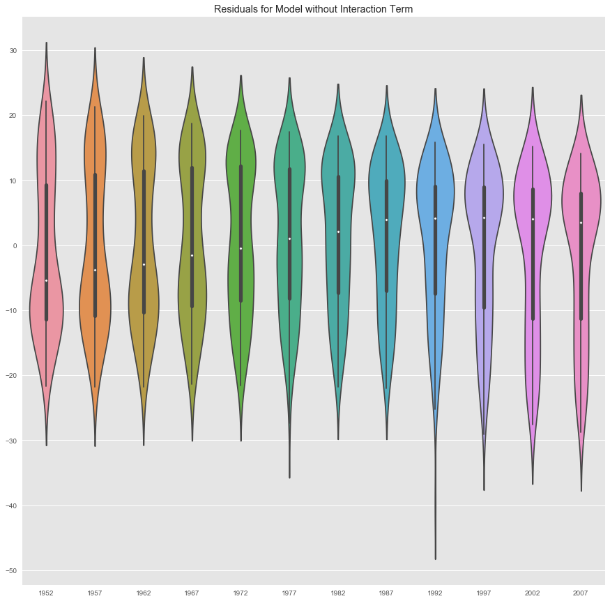

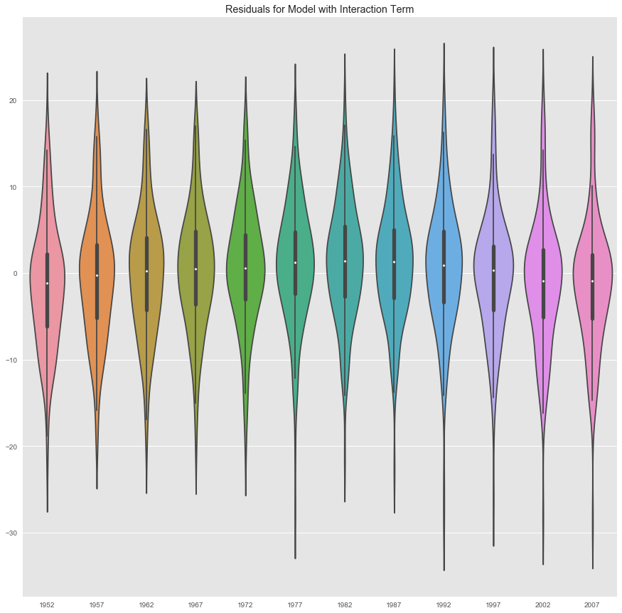

```python
firstModelRes = data['lifeExp'].values - firstModelY.reshape(len(firstModelY))
secondModelRes = data['lifeExp'].values - secondModelY.reshape(len(secondModelY))
q = reg.predict(pd.DataFrame({'continent': data['continent'].values, 'year':data['year'].values}))
r = data['lifeExp'].values - q

fig = plt.figure()
plt.figure(figsize=(15, 15))
plot = sns.violinplot(x=data['year'].values, y=firstModelRes)
plt.title("Residuals for Model without Interaction Term")
plt.show()


fig = plt.figure()
plt.figure(figsize=(15, 15))
plot = sns.violinplot(x=data['year'].values, y=r)
plt.title("Residuals for Model with Interaction Term")
plt.show()
```

We can see that the violins for the model including the ineraction term, exhibit more symmetry, and are closer centered to zero in comparrison to the model without the interaciton term.

# Part 2: Classification

## Problem 1

### Batch Version

```python
def grad_descent(X, y, T, alpha):
    m, n = X.shape
    theta = np.zeros(n)
    f = np.zeros(T)
    for i in range(T):
        f[i] = 0.5*np.linalg.norm(X.dot(theta) - y)**2
        g = X.T.dot(X.dot(theta) - y)
        theta = theta - alpha*g
    return theta, f
```

## Derivation of Update Equation

## $f(x) = \frac{1}{1 + e^{-x}} + \frac{e^x}{1+e^x}$

## ==> $ \frac{d}{dx}f(x)= \frac{e^x*(1 + e^x) - e^x*e^x}{(1+e^x)^2} $

## ==> $ \frac{d}{dx}f(x)= \frac{e^x}{(1+e^x)^2} = f(x)(1 - f(x))$

Derivative of the logistic function has the property such that:

## $ \frac{d}{dx}f(x)= \frac{d}{dx}f(-x)$

### Logistic or Sigmoid Function:

## $f(x) = \frac{1}{1 + e^-x}$

### Derivative of Sigmoid:

## ==> $ \frac{d}{dx}f(x)= \frac{e^x}{(1+e^x)^2} = f(x)(1 - f(x))$

## Logistic Regression:

### $ P(y = 1 | x; \theta ) = h_\theta(x) $

### $ P(y = 0 | x; \theta ) = 1 - h_ \theta(x) $

This can be rewritten as

### $ P (y | x; \theta ) = (h_ \theta(x))^y (1 - h_\theta)^{1-y} $

### So, $ g(x) = h_\theta(x) = g(\theta^{T}x) $ if X $\geq $ 0 and $g(x) \leq $ 0.5 if Z < 0 as we can see

### Linear regression cost function is convex

### $J(\theta) = \frac{1}{2} \sum (h_\theta(x^i) - y^i)^2$

### So , this same cost function for logestic regression is nonconvex because of nonlinear sigmoid function

## $ h_\theta(x) = g(\theta^T x) = \frac{1}{1 + e^{-\theta^Tx}} $

### Cost function for logistic regression

## $ P(y = 1 | x; \theta) = h_\theta(x) $

## $ P(y = 0 | x; \theta) = 1 - h_\theta(x) $

### $ p(y|x; \theta) = (h_\theta(x))^y (1 - h_\theta(x))^{1-y}$

### Instead of minimizing the cost function, we will maximize the log likelihood function:

## $ l (\theta) = logL(\theta) = \sum_{i = 1}^m y^i logh(x^i) + (1 - y^i)log(1 - h(x^i))$

### Given $ g'(x) = g(x)(1 - g(x))$

## $ \frac{\alpha}{\alpha\theta_j}l(\theta) = (y(1 - g(\theta^T)) - (1 - y) g (\theta^Tx)) x_j$

## $= (y - h_\theta(x))x_j $

## $ \theta := \theta + \alpha \triangledown_\theta l(\theta)$

### The parameter updating algorithm

## $\theta_j := \theta_j + \alpha (y^{(i)} - h_\theta (x^{(i)})) x_j^{(i)} $

## Problem 3

### Batch

```python
def sigmoid(p):
    return 1. / (1. + np.exp(-p))

def log_grad(X,y,alpha,iterations):
    m,n = X.shape
    weights = np.zeros(n)
    f = np.zeros(iterations)

    for i in range(iterations):
        y_hat = sigmoid(X.dot(weights))
        f[i] = 0.5*np.linalg.norm(y_hat - y)**2
        ep = y_hat - y
        grad = X.T.dot(ep)
        weights = weights - (alpha * grad)

    return weights, f
```

```python
#simulate data for linear regression

gen_data_x, gen_data_y, gen_coef = sklearn.datasets.make_regression(n_samples=100, n_features=20, noise = 1.5, coef= True)

#simulate data for logistic regression.  This is similar to linear, only now values are either 0 or 1.
log_gen_data_x,dump_y, log_gen_coef = sklearn.datasets.make_regression(n_samples=100, n_features=20, noise = 1.5, coef= True)
log_gen_data_y = [0 if i>0 else 1 for i in dump_y]
```

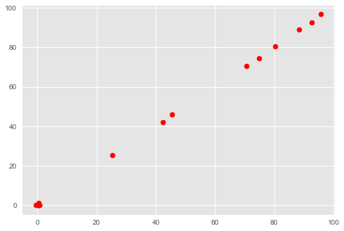

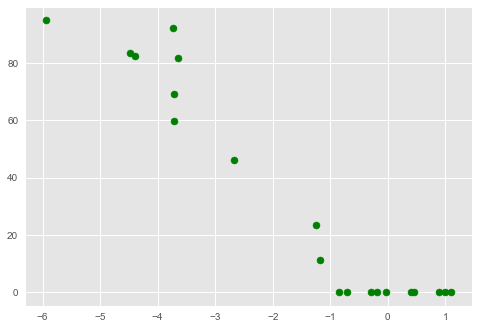

```python
#a really bad estimator
#returns random vector as estimated parameters
dummy = np.ndarray([100, 20])
for index, row in enumerate(dummy):
    dummy[index] = np.random.normal(0, .1, 20)

lin_weights,_ = grad_descent(gen_data_x,gen_data_y,100,.001)
log_weights,_= log_grad(log_gen_data_x,log_gen_data_y,.1,100)

plt.scatter(lin_weights,gen_coef,c="r")
plt.show()

plt.scatter(log_weights,log_gen_coef, c = "g")
plt.show()
```

```python
def k_fold_cross_validation(X, K, randomise = False):
    splits = [[] for x in range(K)]
    for i in range(len(X)):
        splits[i%K].append(X[i])
    return splits


x, y = sklearn.datasets.load_iris(True)
folds = k_fold_cross_validation(x,4)
```

```python
def log_classify(weights, X, Y):
    y = np.round(sigmoid(X.dot(weights)))
    Y = Y.reshape(len(y),1)
    c = np.equal(y,Y).astype(float)
    score = np.sum(c)/len(Y)
    return y ,score

cancer = sklearn.datasets.load_breast_cancer()
K_validate = 10

neigh = sklearn.neighbors.KNeighborsClassifier(n_neighbors=2)
nnScores = sklearn.model_selection.cross_val_score(neigh, cancer.data, cancer.target, cv=K_validate)
# print(nnScores)
svm = sklearn.svm.SVC()
svmScores = sklearn.model_selection.cross_val_score(svm, cancer.data, cancer.target, cv=K_validate)
# print(svmScores)

log_scores = []  #to score log regression scores
for i in range(K_validate):
    xtrain, xtest, ytrain, ytest = sklearn.model_selection.train_test_split(cancer.data, cancer.target, test_size=0.9, random_state=0) #10 CV
    weights,_ = log_grad(xtrain,ytrain,.001,1500) #Gets the trained weights from gradient descent
    _ , score = log_classify(weights, xtest, ytest) #Classifies the data
    log_scores.append(score) #Adds the score to the data

_, p1 = sp.stats.ttest_rel(log_scores,nnScores) #Performs t test to see if the means are statsitcally significantly different
_, p2 = sp.stats.ttest_rel(log_scores,svmScores)
_, p3 = sp.stats.ttest_rel(nnScores,svmScores)
print(p1) # T-test of the log regression vs KNN
print(p2) # T-test of the log regression vs SVM
print(p3) # T-test of the KNN vs SVM
```

```
5.33925355966e-39
1.62560299932e-44
2.98478840318e-12
```